# How does a bike share navigate Speedy Success?

```r
str(tripdata_Sep22)
```

```
## 'data.frame':    785932 obs. of  13 variables:
##  $ ride_id           : chr  "550CF7EFEAE0C618" "DAD198F405F9C5F5" "E6F2BC47B65CB7FD" "F597830181C2E13C" ...
##  $ rideable_type     : chr  "electric_bike" "electric_bike" "electric_bike" "electric_bike" ...
##  $ started_at        : chr  "2022-08-07 21:34:15" "2022-08-08 14:39:21" "2022-08-08 15:29:50" "2022-08-08 02:43:50" ...
##  $ ended_at          : chr  "2022-08-07 21:41:46" "2022-08-08 14:53:23" "2022-08-08 15:40:34" "2022-08-08 02:58:53" ...
##  $ start_station_name: chr  "" "" "" "" ...
##  $ start_station_id  : chr  "" "" "" "" ...
##  $ end_station_name  : chr  "" "" "" "" ...
##  $ end_station_id    : chr  "" "" "" "" ...
##  $ start_lat         : num  41.9 41.9 42 41.9 41.9 ...
##  $ start_lng         : num  -87.7 -87.6 -87.7 -87.7 -87.7 ...
##  $ end_lat           : num  41.9 41.9 42 42 41.8 ...
##  $ end_lng           : num  -87.7 -87.6 -87.7 -87.7 -87.7 ...
##  $ member_casual     : chr  "casual" "casual" "casual" "casual" ...
```

```r
str(tripdata_Oct22)
```

```
## 'data.frame':    701339 obs. of  13 variables:
##  $ ride_id           : chr  "5156990AC19CA285" "E12D4A16BF51C274" "A02B53CD7DB72DD7" "C82E05FEE872DF11" ...
##  $ rideable_type     : chr  "electric_bike" "electric_bike" "electric_bike" "electric_bike" ...
##  $ started_at        : chr  "2022-09-01 08:36:22" "2022-09-01 17:11:29" "2022-09-01 17:15:50" "2022-09-01 09:00:28" ...
##  $ ended_at          : chr  "2022-09-01 08:39:05" "2022-09-01 17:14:45" "2022-09-01 17:16:12" "2022-09-01 09:10:32" ...
##  $ start_station_name: chr  "" "" "" "" ...
##  $ start_station_id  : chr  "" "" "" "" ...
##  $ end_station_name  : chr  "California Ave & Milwaukee Ave" "" "" "" ...
##  $ end_station_id    : chr  "13084" "" "" "" ...
##  $ start_lat         : num  41.9 41.9 41.9 41.9 41.9 ...
##  $ start_lng         : num  -87.7 -87.6 -87.6 -87.7 -87.7 ...
##  $ end_lat           : num  41.9 41.9 41.9 41.9 41.9 ...
##  $ end_lng           : num  -87.7 -87.6 -87.6 -87.7 -87.7 ...
##  $ member_casual     : chr  "casual" "casual" "casual" "casual" ...
```

```r
str(tripdata_Nov22)
```

```
## 'data.frame':    558685 obs. of  13 variables:
##  $ ride_id           : chr  "A50255C1E17942AB" "DB692A70BD2DD4E3" "3C02727AAF60F873" "47E653FDC2D99236" ...
##  $ rideable_type     : chr  "classic_bike" "electric_bike" "electric_bike" "electric_bike" ...
##  $ started_at        : chr  "2022-10-14 17:13:30" "2022-10-01 16:29:26" "2022-10-19 18:55:40" "2022-10-31 07:52:36" ...
##  $ ended_at          : chr  "2022-10-14 17:19:39" "2022-10-01 16:49:06" "2022-10-19 19:03:30" "2022-10-31 07:58:49" ...
##  $ start_station_name: chr  "Noble St & Milwaukee Ave" "Damen Ave & Charleston St" "Hoyne Ave & Balmoral Ave" "Rush St & Cedar St" ...
##  $ start_station_id  : chr  "13290" "13288" "655" "KA1504000133" ...
##  $ end_station_name  : chr  "Larrabee St & Division St" "Damen Ave & Cullerton St" "Western Ave & Leland Ave" "Orleans St & Chestnut St (NEXT Apts)" ...
##  $ end_station_id    : chr  "KA1504000079" "13089" "TA1307000140" "620" ...
##  $ start_lat         : num  41.9 41.9 42 41.9 41.9 ...
##  $ start_lng         : num  -87.7 -87.7 -87.7 -87.6 -87.6 ...
##  $ end_lat           : num  41.9 41.9 42 41.9 41.9 ...
##  $ end_lng           : num  -87.6 -87.7 -87.7 -87.6 -87.6 ...
##  $ member_casual     : chr  "member" "casual" "member" "member" ...
```

```r
str(tripdata_Dec22)
```

```
## 'data.frame':    337735 obs. of  13 variables:
##  $ ride_id           : chr  "BCC66FC6FAB27CC7" "772AB67E902C180F" "585EAD07FDEC0152" "91C4E7ED3C262FF9" ...
##  $ rideable_type     : chr  "electric_bike" "classic_bike" "classic_bike" "classic_bike" ...
##  $ started_at        : chr  "2022-11-10 06:21:55" "2022-11-04 07:31:55" "2022-11-21 17:20:29" "2022-11-25 17:29:34" ...
##  $ ended_at          : chr  "2022-11-10 06:31:27" "2022-11-04 07:46:25" "2022-11-21 17:34:36" "2022-11-25 17:45:15" ...
##  $ start_station_name: chr  "Canal St & Adams St" "Canal St & Adams St" "Indiana Ave & Roosevelt Rd" "Indiana Ave & Roosevelt Rd" ...
##  $ start_station_id  : chr  "13011" "13011" "SL-005" "SL-005" ...
##  $ end_station_name  : chr  "St. Clair St & Erie St" "St. Clair St & Erie St" "St. Clair St & Erie St" "St. Clair St & Erie St" ...
##  $ end_station_id    : chr  "13016" "13016" "13016" "13016" ...
##  $ start_lat         : num  41.9 41.9 41.9 41.9 41.9 ...
##  $ start_lng         : num  -87.6 -87.6 -87.6 -87.6 -87.6 ...
##  $ end_lat           : num  41.9 41.9 41.9 41.9 41.9 ...
##  $ end_lng           : num  -87.6 -87.6 -87.6 -87.6 -87.6 ...
##  $ member_casual     : chr  "member" "member" "member" "member" ...
```

```r
str(tripdata_Jan23)
```

```
## 'data.frame':    181806 obs. of  13 variables:
##  $ ride_id           : chr  "65DBD2F447EC51C2" "0C201AA7EA0EA1AD" "E0B148CCB358A49D" "54C5775D2B7C9188" ...
##  $ rideable_type     : chr  "electric_bike" "classic_bike" "electric_bike" "classic_bike" ...
##  $ started_at        : chr  "2022-12-05 10:47:18" "2022-12-18 06:42:33" "2022-12-13 08:47:45" "2022-12-13 18:50:47" ...
##  $ ended_at          : chr  "2022-12-05 10:56:34" "2022-12-18 07:08:44" "2022-12-13 08:59:51" "2022-12-13 19:19:48" ...
##  $ start_station_name: chr  "Clifton Ave & Armitage Ave" "Broadway & Belmont Ave" "Sangamon St & Lake St" "Shields Ave & 31st St" ...
##  $ start_station_id  : chr  "TA1307000163" "13277" "TA1306000015" "KA1503000038" ...
##  $ end_station_name  : chr  "Sedgwick St & Webster Ave" "Sedgwick St & Webster Ave" "St. Clair St & Erie St" "Damen Ave & Madison St" ...
##  $ end_station_id    : chr  "13191" "13191" "13016" "13134" ...
##  $ start_lat         : num  41.9 41.9 41.9 41.8 41.9 ...
##  $ start_lng         : num  -87.7 -87.6 -87.7 -87.6 -87.7 ...
##  $ end_lat           : num  41.9 41.9 41.9 41.9 41.9 ...
##  $ end_lng           : num  -87.6 -87.6 -87.6 -87.7 -87.7 ...
##  $ member_casual     : chr  "member" "casual" "member" "member" ...
```

```r
str(tripdata_Feb23)
```

```
## 'data.frame':    190301 obs. of  13 variables:
##  $ ride_id           : chr  "F96D5A74A3E41399" "13CB7EB698CEDB88" "BD88A2E670661CE5" "C90792D034FED968" ...
##  $ rideable_type     : chr  "electric_bike" "classic_bike" "electric_bike" "classic_bike" ...
##  $ started_at        : chr  "2023-01-21 20:05:42" "2023-01-10 15:37:36" "2023-01-02 07:51:57" "2023-01-22 10:52:58" ...
##  $ ended_at          : chr  "2023-01-21 20:16:33" "2023-01-10 15:46:05" "2023-01-02 08:05:11" "2023-01-22 11:01:44" ...
##  $ start_station_name: chr  "Lincoln Ave & Fullerton Ave" "Kimbark Ave & 53rd St" "Western Ave & Lunt Ave" "Kimbark Ave & 53rd St" ...
##  $ start_station_id  : chr  "TA1309000058" "TA1309000037" "RP-005" "TA1309000037" ...
##  $ end_station_name  : chr  "Hampden Ct & Diversey Ave" "Greenwood Ave & 47th St" "Valli Produce - Evanston Plaza" "Greenwood Ave & 47th St" ...
##  $ end_station_id    : chr  "202480.0" "TA1308000002" "599" "TA1308000002" ...
##  $ start_lat         : num  41.9 41.8 42 41.8 41.8 ...
##  $ start_lng         : num  -87.6 -87.6 -87.7 -87.6 -87.6 ...
##  $ end_lat           : num  41.9 41.8 42 41.8 41.8 ...
##  $ end_lng           : num  -87.6 -87.6 -87.7 -87.6 -87.6 ...
##  $ member_casual     : chr  "member" "member" "casual" "member" ...
```

```r
str(tripdata_Mar23)
```

```
## 'data.frame':    190445 obs. of  13 variables:
##  $ ride_id           : chr  "CBCD0D7777F0E45F" "F3EC5FCE5FF39DE9" "E54C1F27FA9354FF" "3D561E04F739CC45" ...
##  $ rideable_type     : chr  "classic_bike" "electric_bike" "classic_bike" "electric_bike" ...
##  $ started_at        : chr  "2023-02-14 11:59:42" "2023-02-15 13:53:48" "2023-02-19 11:10:57" "2023-02-26 16:12:05" ...
##  $ ended_at          : chr  "2023-02-14 12:13:38" "2023-02-15 13:59:08" "2023-02-19 11:35:01" "2023-02-26 16:39:55" ...
##  $ start_station_name: chr  "Southport Ave & Clybourn Ave" "Clarendon Ave & Gordon Ter" "Southport Ave & Clybourn Ave" "Southport Ave & Clybourn Ave" ...
##  $ start_station_id  : chr  "TA1309000030" "13379" "TA1309000030" "TA1309000030" ...
##  $ end_station_name  : chr  "Clark St & Schiller St" "Sheridan Rd & Lawrence Ave" "Aberdeen St & Monroe St" "Franklin St & Adams St (Temp)" ...
##  $ end_station_id    : chr  "TA1309000024" "TA1309000041" "13156" "TA1309000008" ...
##  $ start_lat         : num  41.9 42 41.9 41.9 41.8 ...
##  $ start_lng         : num  -87.7 -87.6 -87.7 -87.7 -87.6 ...
##  $ end_lat           : num  41.9 42 41.9 41.9 41.8 ...
##  $ end_lng           : num  -87.6 -87.7 -87.7 -87.6 -87.6 ...
##  $ member_casual     : chr  "casual" "casual" "member" "member" ...
```

```r
str(tripdata_Arp23)
```

```
## 'data.frame':    258678 obs. of  13 variables:
##  $ ride_id           : chr  "6842AA605EE9FBB3" "F984267A75B99A8C" "FF7CF57CFE026D02" "6B61B916032CB6D6" ...
##  $ rideable_type     : chr  "electric_bike" "electric_bike" "classic_bike" "classic_bike" ...
##  $ started_at        : chr  "2023-03-16 08:20:34" "2023-03-04 14:07:06" "2023-03-31 12:28:09" "2023-03-22 14:09:08" ...
##  $ ended_at          : chr  "2023-03-16 08:22:52" "2023-03-04 14:15:31" "2023-03-31 12:38:47" "2023-03-22 14:24:51" ...
##  $ start_station_name: chr  "Clark St & Armitage Ave" "Public Rack - Kedzie Ave & Argyle St" "Orleans St & Chestnut St (NEXT Apts)" "Desplaines St & Kinzie St" ...
##  $ start_station_id  : chr  "13146" "491" "620" "TA1306000003" ...
##  $ end_station_name  : chr  "Larrabee St & Webster Ave" "" "Clark St & Randolph St" "Sheffield Ave & Kingsbury St" ...
##  $ end_station_id    : chr  "13193" "" "TA1305000030" "13154" ...
##  $ start_lat         : num  41.9 42 41.9 41.9 41.9 ...
##  $ start_lng         : num  -87.6 -87.7 -87.6 -87.6 -87.7 ...
##  $ end_lat           : num  41.9 42 41.9 41.9 41.9 ...
##  $ end_lng           : num  -87.6 -87.7 -87.6 -87.7 -87.7 ...
##  $ member_casual     : chr  "member" "member" "member" "member" ...
```

```r
str(tripdata_may23)
```

```
## 'data.frame':    426590 obs. of  13 variables:
##  $ ride_id           : chr  "8FE8F7D9C10E88C7" "34E4ED3ADF1D821B" "5296BF07A2F77CB5" "40759916B76D5D52" ...
##  $ rideable_type     : chr  "electric_bike" "electric_bike" "electric_bike" "electric_bike" ...
##  $ started_at        : chr  "2023-04-02 08:37:28" "2023-04-19 11:29:02" "2023-04-19 08:41:22" "2023-04-19 13:31:30" ...
##  $ ended_at          : chr  "2023-04-02 08:41:37" "2023-04-19 11:52:12" "2023-04-19 08:43:22" "2023-04-19 13:35:09" ...
##  $ start_station_name: chr  "" "" "" "" ...
##  $ start_station_id  : chr  "" "" "" "" ...
##  $ end_station_name  : chr  "" "" "" "" ...
##  $ end_station_id    : chr  "" "" "" "" ...
##  $ start_lat         : num  41.8 41.9 41.9 41.9 41.9 ...
##  $ start_lng         : num  -87.6 -87.7 -87.7 -87.7 -87.7 ...
##  $ end_lat           : num  41.8 41.9 41.9 41.9 41.9 ...
##  $ end_lng           : num  -87.6 -87.7 -87.7 -87.7 -87.6 ...
##  $ member_casual     : chr  "member" "member" "member" "member" ...
```

```r
str(tripdata_Jun23)
```

```
## 'data.frame':    604827 obs. of  13 variables:
##  $ ride_id           : chr  "0D9FA920C3062031" "92485E5FB5888ACD" "FB144B3FC8300187" "DDEB93BC2CE9AA77" ...
##  $ rideable_type     : chr  "electric_bike" "electric_bike" "electric_bike" "classic_bike" ...
##  $ started_at        : chr  "2023-05-07 19:53:48" "2023-05-06 18:54:08" "2023-05-21 00:40:21" "2023-05-10 16:47:01" ...
##  $ ended_at          : chr  "2023-05-07 19:58:32" "2023-05-06 19:03:35" "2023-05-21 00:44:36" "2023-05-10 16:59:52" ...
##  $ start_station_name: chr  "Southport Ave & Belmont Ave" "Southport Ave & Belmont Ave" "Halsted St & 21st St" "Carpenter St & Huron St" ...
##  $ start_station_id  : chr  "13229" "13229" "13162" "13196" ...
##  $ end_station_name  : chr  "" "" "" "Damen Ave & Cortland St" ...
##  $ end_station_id    : chr  "" "" "" "13133" ...
##  $ start_lat         : num  41.9 41.9 41.9 41.9 42 ...
##  $ start_lng         : num  -87.7 -87.7 -87.6 -87.7 -87.7 ...
##  $ end_lat           : num  41.9 41.9 41.9 41.9 41.9 ...
##  $ end_lng           : num  -87.7 -87.7 -87.7 -87.7 -87.7 ...
##  $ member_casual     : chr  "member" "member" "member" "member" ...
```

```r
str(tripdata_Jul23)
```

```
## 'data.frame':    719618 obs. of  13 variables:
##  $ ride_id           : chr  "6F1682AC40EB6F71" "622A1686D64948EB" "3C88859D926253B4" "EAD8A5E0259DEC88" ...
##  $ rideable_type     : chr  "electric_bike" "electric_bike" "electric_bike" "electric_bike" ...
##  $ started_at        : chr  "2023-06-05 13:34:12" "2023-06-05 01:30:22" "2023-06-20 18:15:49" "2023-06-19 14:56:00" ...
##  $ ended_at          : chr  "2023-06-05 14:31:56" "2023-06-05 01:33:06" "2023-06-20 18:32:05" "2023-06-19 15:00:35" ...
##  $ start_station_name: chr  "" "" "" "" ...
##  $ start_station_id  : chr  "" "" "" "" ...
##  $ end_station_name  : chr  "" "" "" "" ...
##  $ end_station_id    : chr  "" "" "" "" ...
##  $ start_lat         : num  41.9 41.9 42 42 42 ...
##  $ start_lng         : num  -87.7 -87.7 -87.7 -87.7 -87.7 ...
##  $ end_lat           : num  41.9 41.9 41.9 42 42 ...
##  $ end_lng           : num  -87.7 -87.7 -87.6 -87.7 -87.7 ...
##  $ member_casual     : chr  "member" "member" "member" "member" ...
```

```r
str(tripdata_Aug23)
```

```
## 'data.frame':    767650 obs. of  13 variables:
##  $ ride_id           : chr  "9340B064F0AEE130" "D1460EE3CE0D8AF8" "DF41BE31B895A25E" "9624A293749EF703" ...
##  $ rideable_type     : chr  "electric_bike" "classic_bike" "classic_bike" "electric_bike" ...
##  $ started_at        : chr  "2023-07-23 20:06:14" "2023-07-23 17:05:07" "2023-07-23 10:14:53" "2023-07-21 08:27:44" ...
##  $ ended_at          : chr  "2023-07-23 20:22:44" "2023-07-23 17:18:37" "2023-07-23 10:24:29" "2023-07-21 08:32:40" ...
##  $ start_station_name: chr  "Kedzie Ave & 110th St" "Western Ave & Walton St" "Western Ave & Walton St" "Racine Ave & Randolph St" ...
##  $ start_station_id  : chr  "20204" "KA1504000103" "KA1504000103" "13155" ...
##  $ end_station_name  : chr  "Public Rack - Racine Ave & 109th Pl" "Milwaukee Ave & Grand Ave" "Damen Ave & Pierce Ave" "Clinton St & Madison St" ...
##  $ end_station_id    : chr  "877" "13033" "TA1305000041" "TA1305000032" ...
##  $ start_lat         : num  41.7 41.9 41.9 41.9 42 ...
##  $ start_lng         : num  -87.7 -87.7 -87.7 -87.7 -87.7 ...
##  $ end_lat           : num  41.7 41.9 41.9 41.9 42 ...
##  $ end_lng           : num  -87.7 -87.6 -87.7 -87.6 -87.6 ...
##  $ member_casual     : chr  "member" "member" "member" "member" ...
```

```r
#Confirmed
```

```r
#Convert some data type (from Double to Character) to merge
tripdata_Aug22 <- mutate(tripdata_Aug22, start_station_id= as.character(start_station_id), end_station_id=as.character(end_station_id))
tripdata_Sep22 <- mutate(tripdata_Sep22, start_station_id= as.character(start_station_id), end_station_id=as.character(end_station_id))
tripdata_Oct22 <- mutate(tripdata_Oct22, start_station_id= as.character(start_station_id), end_station_id=as.character(end_station_id))
tripdata_Nov22 <- mutate(tripdata_Nov22, start_station_id= as.character(start_station_id), end_station_id=as.character(end_station_id))
tripdata_Dec22 <- mutate(tripdata_Dec22, start_station_id= as.character(start_station_id), end_station_id=as.character(end_station_id))
tripdata_Jan23 <- mutate(tripdata_Jan23, start_station_id= as.character(start_station_id), end_station_id=as.character(end_station_id))
tripdata_Feb23 <- mutate(tripdata_Feb23, start_station_id= as.character(start_station_id), end_station_id=as.character(end_station_id))
tripdata_Mar23 <- mutate(tripdata_Mar23, start_station_id= as.character(start_station_id), end_station_id=as.character(end_station_id))
tripdata_Arp23 <- mutate(tripdata_Arp23, start_station_id= as.character(start_station_id), end_station_id=as.character(end_station_id))
tripdata_may23 <- mutate(tripdata_may23, start_station_id= as.character(start_station_id), end_station_id=as.character(end_station_id))
tripdata_Jun23 <- mutate(tripdata_Jun23, start_station_id= as.character(start_station_id), end_station_id=as.character(end_station_id))
tripdata_Jul23 <- mutate(tripdata_Jul23, start_station_id= as.character(start_station_id), end_station_id=as.character(end_station_id))
tripdata_Aug23 <- mutate(tripdata_Aug23, start_station_id= as.character(start_station_id), end_station_id=as.character(end_station_id))
```

```r
#Combine all the data sets
All_trips<- bind_rows(tripdata_Aug22,tripdata_Sep22,tripdata_Oct22,tripdata_Nov22,tripdata_Dec22,tripdata_Jan23,tripdata_Feb23,tripdata_Mar23,tripdata_Arp23,tripdata_may23,tripdata_Jun23,tripdata_Jul23,tripdata_Aug23)
```

**Process**

I have done Data Cleaning using R due to large data set.

```r
#List of all column names
colnames(All_trips)
```

```
##  [1] "ride_id"            "rideable_type"      "started_at"
##  [4] "ended_at"           "start_station_name" "start_station_id"
##  [7] "end_station_name"   "end_station_id"     "start_lat"
## [10] "start_lng"          "end_lat"            "end_lng"
## [13] "member_casual"
```

```r
#How many rows are in data frames?
nrow(All_trips)
```

```
## [1] 6547094
```

```r
#Dimension of the data frame
dim(All_trips)
```

```
## [1] 6547094      13
```

```r
#First 6 rows of data frame
head(All_trips)
```

```
##            ride_id rideable_type          started_at            ended_at
## 1 954144C2F67B1932  classic_bike 2022-07-05 08:12:47 2022-07-05 08:24:32
## 2 292E027607D218B6  classic_bike 2022-07-26 12:53:38 2022-07-26 12:55:31
## 3 57765852588AD6E0  classic_bike 2022-07-03 13:58:49 2022-07-03 14:06:32
## 4 B5B6BE44314590E6  classic_bike 2022-07-31 17:44:21 2022-07-31 18:42:50
## 5 A4C331F2A00E79E0  classic_bike 2022-07-13 19:49:06 2022-07-13 20:15:24
## 6 579D73BE2ED880B3 electric_bike 2022-07-01 17:04:35 2022-07-01 17:13:18
##            start_station_name start_station_id               end_station_name
## 1  Ashland Ave & Blackhawk St            13224       Kingsbury St & Kinzie St
## 2  Buckingham Fountain (Temp)            15541          Michigan Ave & 8th St
## 3  Buckingham Fountain (Temp)            15541          Michigan Ave & 8th St
## 4  Buckingham Fountain (Temp)            15541         Woodlawn Ave & 55th St
## 5      Wabash Ave & Grand Ave     TA1307000117 Sheffield Ave & Wellington Ave
## 6 Desplaines St & Randolph St            15535      Clinton St & Roosevelt Rd
##   end_station_id start_lat start_lng  end_lat   end_lng member_casual
## 1   KA1503000043  41.90707 -87.66725 41.88918 -87.63851        member
## 2            623  41.86962 -87.62398 41.87277 -87.62398        casual
## 3            623  41.86962 -87.62398 41.87277 -87.62398        casual
## 4   TA1307000164  41.86962 -87.62398 41.79526 -87.59647        casual
## 5   TA1307000052  41.89147 -87.62676 41.93625 -87.65266        member
## 6         WL-008  41.88461 -87.64456 41.86712 -87.64109        member
```

```r
#See list of columns and data types(numeric, character,etc)
str(All_trips)
```

```
## 'data.frame':    6547094 obs. of  13 variables:
##  $ ride_id           : chr  "954144C2F67B1932" "292E027607D218B6" "57765852588AD6E0" "B5B6BE44314590E6" ...
##  $ rideable_type     : chr  "classic_bike" "classic_bike" "classic_bike" "classic_bike" ...
##  $ started_at        : chr  "2022-07-05 08:12:47" "2022-07-26 12:53:38" "2022-07-03 13:58:49" "2022-07-31 17:44:21" ...
##  $ ended_at          : chr  "2022-07-05 08:24:32" "2022-07-26 12:55:31" "2022-07-03 14:06:32" "2022-07-31 18:42:50" ...
##  $ start_station_name: chr  "Ashland Ave & Blackhawk St" "Buckingham Fountain (Temp)" "Buckingham Fountain (Temp)" "Buckingham Fountain (Temp)" ...
##  $ start_station_id  : chr  "13224" "15541" "15541" "15541" ...
##  $ end_station_name  : chr  "Kingsbury St & Kinzie St" "Michigan Ave & 8th St" "Michigan Ave & 8th St" "Woodlawn Ave & 55th St" ...
##  $ end_station_id    : chr  "KA1503000043" "623" "623" "TA1307000164" ...
##  $ start_lat         : num  41.9 41.9 41.9 41.9 41.9 ...
##  $ start_lng         : num  -87.7 -87.6 -87.6 -87.6 -87.6 ...
##  $ end_lat           : num  41.9 41.9 41.9 41.8 41.9 ...
##  $ end_lng           : num  -87.6 -87.6 -87.6 -87.6 -87.7 ...
##  $ member_casual     : chr  "member" "casual" "casual" "casual" ...
```

```r
#Statistical summary of data. Mainly for numerics.
summary(All_trips)
```

```
##    ride_id          rideable_type       started_at          ended_at
##  Length:6547094     Length:6547094     Length:6547094     Length:6547094
##  Class :character   Class :character   Class :character   Class :character
##  Mode  :character   Mode  :character   Mode  :character   Mode  :character
##
##
##
##
##  start_station_name start_station_id   end_station_name   end_station_id
##  Length:6547094     Length:6547094     Length:6547094     Length:6547094
##  Class :character   Class :character   Class :character   Class :character
##  Mode  :character   Mode  :character   Mode  :character   Mode  :character
##
##
##
##
##    start_lat       start_lng         end_lat         end_lng
##  Min.   :41.64   Min.   :-87.92   Min.   : 0.00   Min.   :-88.16
##  1st Qu.:41.88   1st Qu.:-87.66   1st Qu.:41.88   1st Qu.:-87.66
##  Median :41.90   Median :-87.64   Median :41.90   Median :-87.64
##  Mean   :41.90   Mean   :-87.65   Mean   :41.90   Mean   :-87.65
##  3rd Qu.:41.93   3rd Qu.:-87.63   3rd Qu.:41.93   3rd Qu.:-87.63
##  Max.   :42.07   Max.   :-87.52   Max.   :42.37   Max.   :  0.00
##                                   NA's   :7049    NA's   :7049
##  member_casual
##  Length:6547094
##  Class :character
##  Mode  :character
##
##
##
##
```

Confirmed there are 7049 NA columns in end_lat and end_lng.

```r
#Add columns that list the date, month,day and year of each ride as we might need to aggregate ride data for each month, day or year.
All_trips$date<- as.Date(All_trips$started_at)# The default format is YYYY-MM-DD
All_trips$month<-format(as.Date(All_trips$date),"%m")
All_trips$day <-format(as.Date(All_trips$date),"%d")
All_trips$year<-format(as.Date(All_trips$date),"%Y")
All_trips$day_of_week<-format(as.Date(All_trips$date),"%A")
```

Let’s check if additional columns have been added.

```r
colnames(All_trips)#Check additional column added
```

```
##  [1] "ride_id"            "rideable_type"      "started_at"
##  [4] "ended_at"           "start_station_name" "start_station_id"
##  [7] "end_station_name"   "end_station_id"     "start_lat"
## [10] "start_lng"          "end_lat"            "end_lng"
## [13] "member_casual"      "date"               "month"
## [16] "day"                "year"               "day_of_week"
```

Confirmed additional columns have been added

Calculate ride_length to All_trips so that I can compare ride length for each ride.

```r
All_trips$ride_length <-difftime(All_trips$ended_at,All_trips$started_at)
```

```r
#Convert" "ride_length" from double to numeric so we can run calculations on the data
All_trips$ride_length <- as.numeric(as.character(All_trips$ride_length))
is.numeric(All_trips$ride_length)
```

```
## [1] TRUE
```

*Remove Bad data*

```r
All_trips_v2 <- All_trips[!(All_trips$ride_length <= 0 | All_trips$ride_length > 1440),]
```

```r
#Check new dataframe
dim(All_trips_v2)
```

```
## [1] 5545660      19
```

```r
View(All_trips_v2)
summary(All_trips_v2)
```

```
##    ride_id          rideable_type       started_at          ended_at
##  Length:5545660     Length:5545660     Length:5545660     Length:5545660
##  Class :character   Class :character   Class :character   Class :character
##  Mode  :character   Mode  :character   Mode  :character   Mode  :character
##
##
##
##
##  start_station_name start_station_id   end_station_name   end_station_id
##  Length:5545660     Length:5545660     Length:5545660     Length:5545660
##  Class :character   Class :character   Class :character   Class :character
##  Mode  :character   Mode  :character   Mode  :character   Mode  :character
##
##
##
##
##    start_lat       start_lng         end_lat         end_lng
##  Min.   :41.64   Min.   :-87.92   Min.   : 0.00   Min.   :-87.92
##  1st Qu.:41.88   1st Qu.:-87.66   1st Qu.:41.88   1st Qu.:-87.66
##  Median :41.90   Median :-87.65   Median :41.90   Median :-87.65
##  Mean   :41.90   Mean   :-87.65   Mean   :41.90   Mean   :-87.65
##  3rd Qu.:41.93   3rd Qu.:-87.63   3rd Qu.:41.93   3rd Qu.:-87.63
##  Max.   :42.07   Max.   :-87.52   Max.   :42.12   Max.   :  0.00
##                                   NA's   :187     NA's   :187
##  member_casual           date               month               day
##  Length:5545660     Min.   :2022-07-01   Length:5545660     Length:5545660
##  Class :character   1st Qu.:2022-09-05   Class :character   Class :character
##  Mode  :character   Median :2022-12-11   Mode  :character   Mode  :character
##                     Mean   :2023-01-07
##                     3rd Qu.:2023-05-23
##                     Max.   :2023-07-31
##
##      year           day_of_week         ride_length
##  Length:5545660     Length:5545660     Min.   :   1.0
##  Class :character   Class :character   1st Qu.: 301.0
##  Mode  :character   Mode  :character   Median : 502.0
##                                        Mean   : 568.6
##                                        3rd Qu.: 792.0
##                                        Max.   :1440.0
##
```

Confirmed the total number of rows 5545660. 187 Na’s remains in end_lat and end_lng.

Remove NA data from the All_trips_v2 to get accurate data

```r
All_trips_v2 <- drop_na(All_trips_v2)#Drop all NAs
dim(All_trips_v2)
```

```
## [1] 5545473      19
```

```r
summary(All_trips_v2)
```

```
##    ride_id          rideable_type       started_at          ended_at
##  Length:5545473     Length:5545473     Length:5545473     Length:5545473
##  Class :character   Class :character   Class :character   Class :character
##  Mode  :character   Mode  :character   Mode  :character   Mode  :character
##
##
##
##  start_station_name start_station_id   end_station_name   end_station_id
##  Length:5545473     Length:5545473     Length:5545473     Length:5545473
##  Class :character   Class :character   Class :character   Class :character
##  Mode  :character   Mode  :character   Mode  :character   Mode  :character
##
##
##
##    start_lat       start_lng         end_lat         end_lng
##  Min.   :41.64   Min.   :-87.92   Min.   : 0.00   Min.   :-87.92
##  1st Qu.:41.88   1st Qu.:-87.66   1st Qu.:41.88   1st Qu.:-87.66
##  Median :41.90   Median :-87.65   Median :41.90   Median :-87.65
##  Mean   :41.90   Mean   :-87.65   Mean   :41.90   Mean   :-87.65
##  3rd Qu.:41.93   3rd Qu.:-87.63   3rd Qu.:41.93   3rd Qu.:-87.63
##  Max.   :42.07   Max.   :-87.52   Max.   :42.12   Max.   :  0.00
##  member_casual           date               month               day
##  Length:5545473     Min.   :2022-07-01   Length:5545473     Length:5545473
##  Class :character   1st Qu.:2022-09-05   Class :character   Class :character
##  Mode  :character   Median :2022-12-11   Mode  :character   Mode  :character
##                     Mean   :2023-01-07
##                     3rd Qu.:2023-05-23
##                     Max.   :2023-07-31
##      year           day_of_week         ride_length
##  Length:5545473     Length:5545473     Min.   :   1.0
##  Class :character   Class :character   1st Qu.: 301.0
##  Mode  :character   Mode  :character   Median : 502.0
##                                        Mean   : 568.6
##                                        3rd Qu.: 792.0
##                                        Max.   :1440.0
```

Remove duplicate ID as I confirmed ride ID is associate with each rides. It confirmed different ride_id is assigned for every rides even if same r ider uses uses this service

```r
All_trips_v3<-All_trips_v2[!duplicated(All_trips_v2$ride_id),]
dim(All_trips_v3)
```

```
## [1] 5545473      19
```

Data Cleaning/Validation process has been completed at this point.I have created one additional columns for further analysis i.e Distance for each ride

```r
library(geosphere)
start_matrix= matrix(c(All_trips_v3$start_lng, All_trips_v3$start_lat), ncol=2)
end_matrix= matrix(c(All_trips_v3$end_lng, All_trips_v3$end_lat), ncol=2)
```

```r
#Find out the distance for each ride
All_trips_v3$ride_distance<- distGeo(start_matrix,end_matrix)
View(All_trips_v3)
```

```r
summary(All_trips_v3)
```

```
##    ride_id          rideable_type       started_at          ended_at
##  Length:5545473     Length:5545473     Length:5545473     Length:5545473
##  Class :character   Class :character   Class :character   Class :character
##  Mode  :character   Mode  :character   Mode  :character   Mode  :character
##
##
##
##  start_station_name start_station_id   end_station_name   end_station_id
##  Length:5545473     Length:5545473     Length:5545473     Length:5545473
##  Class :character   Class :character   Class :character   Class :character
##  Mode  :character   Mode  :character   Mode  :character   Mode  :character
##
##
##
##    start_lat       start_lng         end_lat         end_lng
##  Min.   :41.64   Min.   :-87.92   Min.   : 0.00   Min.   :-87.92
##  1st Qu.:41.88   1st Qu.:-87.66   1st Qu.:41.88   1st Qu.:-87.66
##  Median :41.90   Median :-87.65   Median :41.90   Median :-87.65
##  Mean   :41.90   Mean   :-87.65   Mean   :41.90   Mean   :-87.65
##  3rd Qu.:41.93   3rd Qu.:-87.63   3rd Qu.:41.93   3rd Qu.:-87.63
##  Max.   :42.07   Max.   :-87.52   Max.   :42.12   Max.   :  0.00
##  member_casual           date               month               day
##  Length:5545473     Min.   :2022-07-01   Length:5545473     Length:5545473
##  Class :character   1st Qu.:2022-09-05   Class :character   Class :character
##  Mode  :character   Median :2022-12-11   Mode  :character   Mode  :character
##                     Mean   :2023-01-07
##                     3rd Qu.:2023-05-23
##                     Max.   :2023-07-31
##      year           day_of_week         ride_length     ride_distance
##  Length:5545473     Length:5545473     Min.   :   1.0   Min.   :      0
##  Class :character   Class :character   1st Qu.: 301.0   1st Qu.:    854
##  Mode  :character   Mode  :character   Median : 502.0   Median :   1446
##                                        Mean   : 568.6   Mean   :   1794
##                                        3rd Qu.: 792.0   3rd Qu.:   2407
##                                        Max.   :1440.0   Max.   :9818680
```

**Analysis**

Find out the number of ride by type of rider.

```r
All_trips_v3$day_of_week <- replace(All_trips_v3$day_of_week,NA,"Sunday")
```

```r
#Assign the correct order to each day of the week
All_trips_v3$day_of_week <- ordered(All_trips_v3$day_of_week, levels=c('Monday','Tuesday','Wednesday','Thursday','Friday','Saturday','Sunday'))
```

```r
All_trips_v3 %>%
  group_by(member_casual,day_of_week) %>%
  summarize(number_of_ride =n(), .groups = 'drop') %>%
  arrange(day_of_week)
```

```
## # A tibble: 14 × 3
##    member_casual day_of_week number_of_ride
##    <chr>         <ord>                <int>
##  1 casual        Monday              232827
##  2 member        Monday              500353
##  3 casual        Tuesday             240150
##  4 member        Tuesday             553944
##  5 casual        Wednesday           250824
##  6 member        Wednesday           569882
##  7 casual        Thursday            274587
##  8 member        Thursday            573761
##  9 casual        Friday              305606
## 10 member        Friday              521628
## 11 casual        Saturday            380561
## 12 member        Saturday            460379
## 13 casual        Sunday              294206
## 14 member        Sunday              386765
```

```r
# Assign the correct order to each month of the year
All_trips_v3$month <- ordered(All_trips_v3$month, levels=c('08','09','10','11','12','01','02','03','04','05','06','07'))
```

```r
All_trips_v3 %>%
  group_by(member_casual,month) %>%
  summarize(number_of_rides =n(), .groups ='drop') %>%
  arrange(month)
```

```
## # A tibble: 24 × 3
##    member_casual month number_of_rides
##    <chr>         <ord>           <int>
##  1 casual        08             270539
##  2 member        08             375595
##  3 casual        09             231311
##  4 member        09             360428
##  5 casual        10             168072
##  6 member        10             318845
##  7 casual        11              85953
##  8 member        11             219216
##  9 casual        12              40448
## 10 member        12             128315
## # ℹ 14 more rows
```

*Finding*

1.Casual riders are more likely to take a ride on weekend while membership riders use on weekday more often. 2. Summer is the peak season for both riders types.

Now,I would like to find out whether ride_length can be different depends on rider types

```r
aggregate(All_trips_v3$ride_length ~ All_trips_v3$member_casual + All_trips_v3$day_of_week,FUN=mean)
```

```
##    All_trips_v3$member_casual All_trips_v3$day_of_week All_trips_v3$ride_length
## 1                      casual                   Monday                 603.2290
## 2                      member                   Monday                 523.9108
## 3                      casual                  Tuesday                 593.0419
## 4                      member                  Tuesday                 530.7149
## 5                      casual                Wednesday                 592.5294
## 6                      member                Wednesday                 534.1803
## 7                      casual                 Thursday                 599.6171
## 8                      member                 Thursday                 536.3308
## 9                      casual                   Friday                 619.2496
## 10                     member                   Friday                 535.6599
## 11                     casual                 Saturday                 661.4409
## 12                     member                 Saturday                 568.3961
## 13                     casual                   Sunday                 651.0226
## 14                     member                   Sunday                 556.1361
```

```r
All_trips_v3 %>%
  group_by(member_casual, month) %>%
  summarise(average_ride_length = mean(ride_length), .groups = 'drop') %>%
  arrange(month)
```

```
## # A tibble: 24 × 3
##    member_casual month average_ride_length
##    <chr>         <ord>               <dbl>
##  1 casual        08                   646.
##  2 member        08                   575.
##  3 casual        09                   627.
##  4 member        09                   557.
##  5 casual        10                   590.
##  6 member        10                   521.
##  7 casual        11                   547.
##  8 member        11                   502.
##  9 casual        12                   516.
## 10 member        12                   484.
## # ℹ 14 more rows
```

*Finding*

1.Casual rider’s trip is longer than membership ones regardless of the season or day 2.All users take longer trips over weekend and summer.

```r
All_trips_v3 %>%
  group_by(member_casual, day_of_week) %>%
  summarise(distance_of_ride = mean(ride_distance), .groups = 'drop') %>%
  arrange(day_of_week)
```

```
## # A tibble: 14 × 3
##    member_casual day_of_week distance_of_ride
##    <chr>         <ord>                  <dbl>
##  1 casual        Monday                 1711.
##  2 member        Monday                 1753.
##  3 casual        Tuesday                1751.
##  4 member        Tuesday                1787.
##  5 casual        Wednesday              1849.
##  6 member        Wednesday              1906.
##  7 casual        Thursday               1811.
##  8 member        Thursday               1820.
##  9 casual        Friday                 1746.
## 10 member        Friday                 1765.
## 11 casual        Saturday               1766.
## 12 member        Saturday               1818.
## 13 casual        Sunday                 1753.
## 14 member        Sunday                 1791.
```

```r
All_trips_v3 %>%
  group_by(member_casual, month) %>%
  summarise(distance_of_ride = mean(ride_distance), .groups='drop') %>%
  arrange(month)
```

```
## # A tibble: 24 × 3
##    member_casual month distance_of_ride
##    <chr>         <ord>            <dbl>
##  1 casual        08               1820.
##  2 member        08               1869.
##  3 casual        09               1796.
##  4 member        09               1815.
##  5 casual        10               1714.
##  6 member        10               1727.
##  7 casual        11               1869.
##  8 member        11               1954.
##  9 casual        12               1551.
## 10 member        12               1622.
## # ℹ 14 more rows
```

Finally, Let’s find out how many riders use the same bike station for start point and end point(ride_distance=0)

```r
All_trips_v3 %>%
  group_by(member_casual) %>%
  summarise(number_of_rides = n(), .groups = 'drop')
```

```
## # A tibble: 2 × 2
##   member_casual number_of_rides
##   <chr>                   <int>
## 1 casual                1978761
## 2 member                3566712
```

```r
All_trips_v3 %>%
  group_by(member_casual) %>%
  filter(ride_distance < 1) %>%
  summarise(number_of_rides = n(), .groups = 'drop')
```

```
## # A tibble: 2 × 2
##   member_casual number_of_rides
##   <chr>                   <int>
## 1 casual                 126785
## 2 member                 121763
```

*Finding*

While 6% of casual riders return their bike to their start point, 3% of membership rider returns at their start point station.

**Share**

I would like to share visualization which would allow executives to understand my conclusion easily.

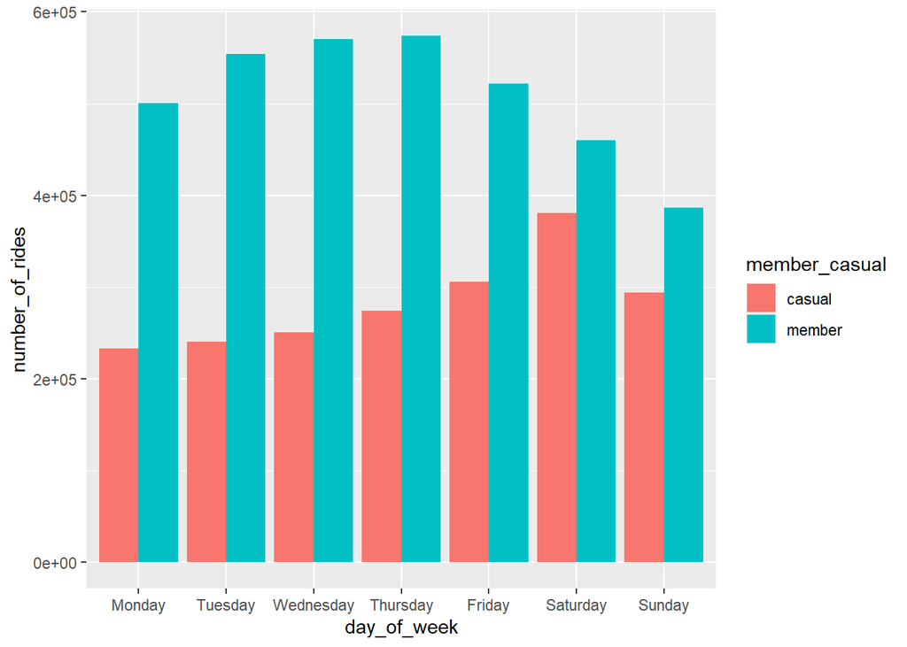

```r
All_trips_v3 %>%
  group_by(member_casual,day_of_week) %>%
  summarise(number_of_rides =n(), .groups = 'drop') %>%
  ggplot(aes(x= day_of_week, y= number_of_rides ,fill = member_casual)) +
  geom_bar(position = "dodge",stat ="identity")
```

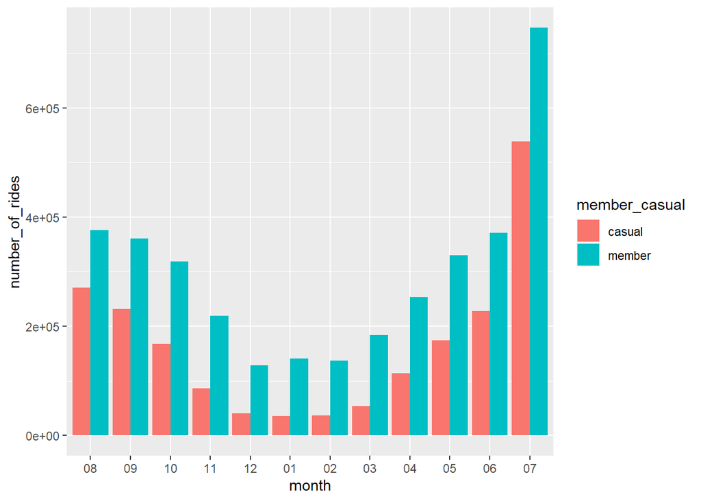

```r
All_trips_v3 %>%
  group_by(member_casual,month) %>%
  summarise(number_of_rides =n(), .groups = 'drop') %>%
  ggplot(aes(x= month, y= number_of_rides ,fill = member_casual)) +
  geom_bar(position = "dodge",stat ="identity")
```

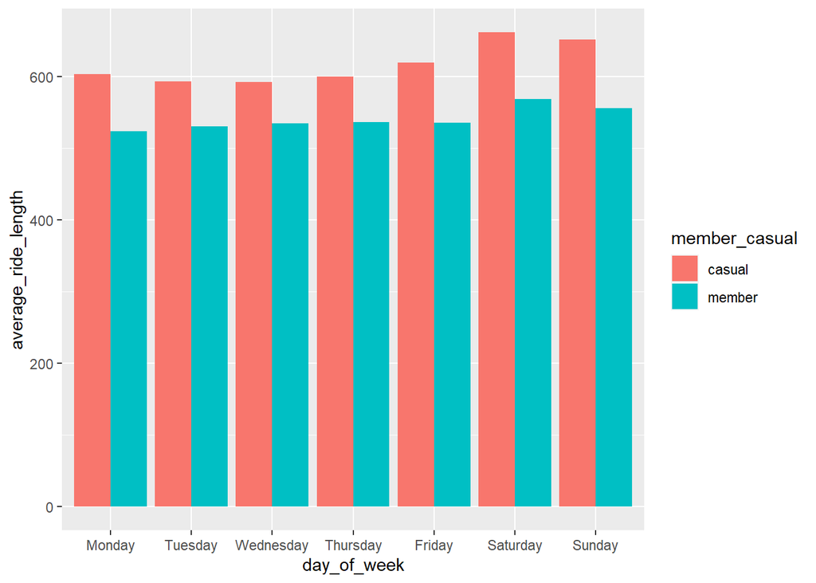

```r
All_trips_v3 %>%
  group_by(member_casual, day_of_week) %>%
  summarise(average_ride_length = mean(ride_length), .groups = 'drop')%>%
  ggplot(aes(x=day_of_week, y=average_ride_length, fill =member_casual)) +
  geom_bar(position = "dodge", stat = "identity")
```

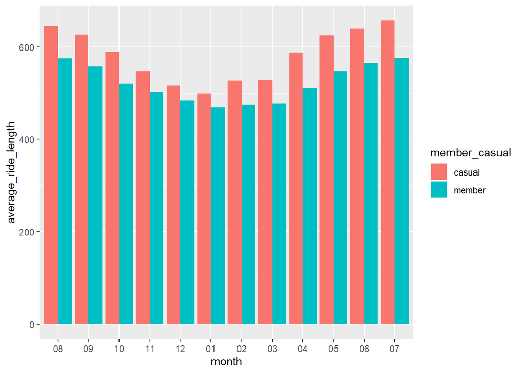

```r
All_trips_v3 %>%
  group_by(member_casual, month) %>%
  summarise(average_ride_length = mean(ride_length), .groups = 'drop')%>%
  ggplot(aes(x=month, y=average_ride_length, fill =member_casual)) +
  geom_bar(position = "dodge", stat = "identity")
```

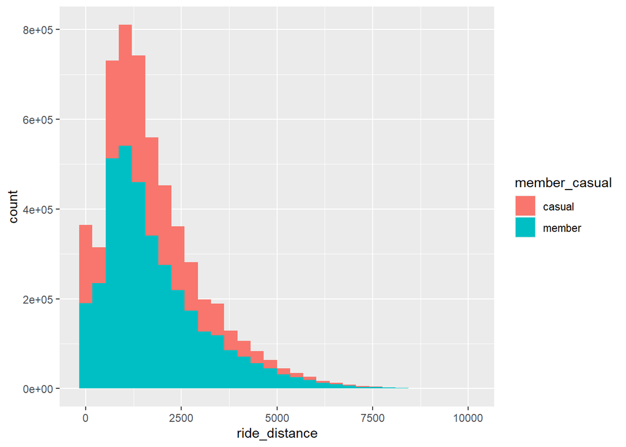

```r
All_trips_v3 %>%
  filter(ride_distance < 10000) %>%
  ggplot(aes(x=ride_distance, fill= member_casual)) +
  geom_histogram()
```

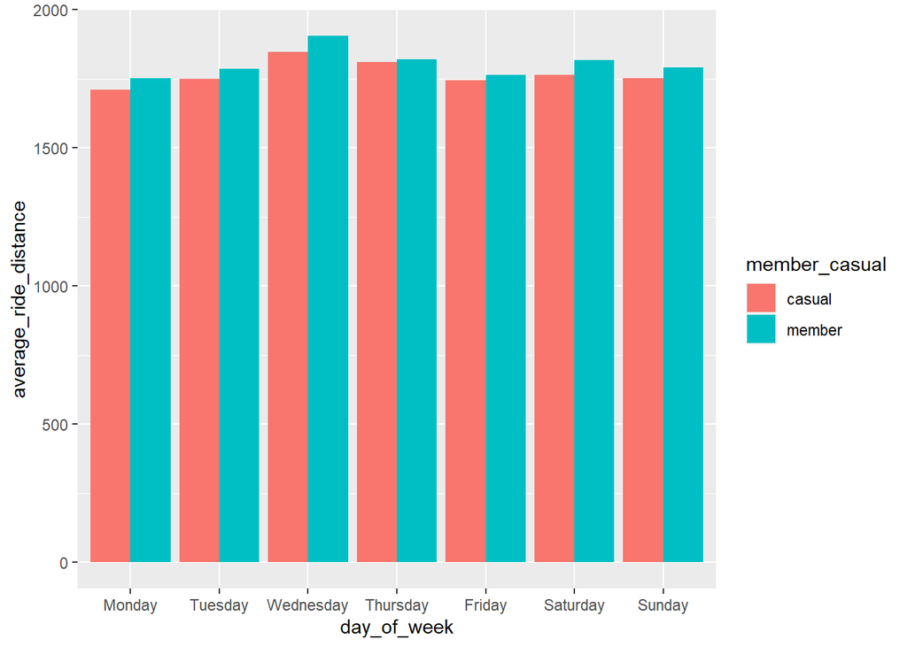

```r
All_trips_v3 %>%
  group_by(member_casual, day_of_week) %>%
  summarise(average_ride_distance = mean(ride_distance), .groups = 'drop')%>%
  ggplot(aes(x=day_of_week, y=average_ride_distance, fill =member_casual)) +
  geom_bar(position = "dodge", stat = "identity")
```

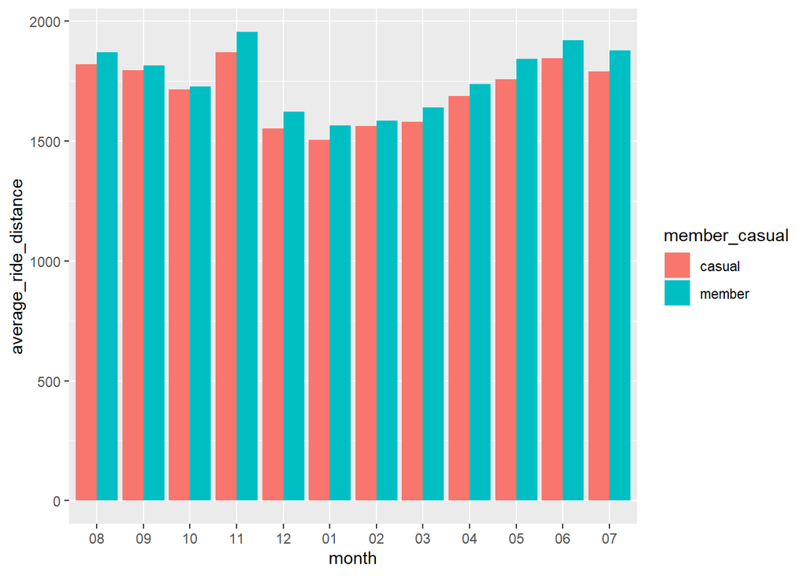

```r
All_trips_v3 %>%
  group_by(member_casual, month) %>%
  summarise(average_ride_distance = mean(ride_distance), .groups = 'drop')%>%
  ggplot(aes(x=month, y=average_ride_distance, fill =member_casual)) +
  geom_bar(position = "dodge", stat = "identity")
```

**Conclusion**

**Recommendation**

To convert casual riders into annual members, the following marketing strategies can be implemented:

1. We can provide offer and discount to casual member if they convert member for weekends and monsoons.
2. We can increase rental prices for weekends for casual rides so that they have certain incentive to convert to members.